# Liste de problèmes sur **R** et **Rmd**

DU Qiming email : duqiming2004@gmail.com

autome 2017

Je donne une liste des problèmes posés par les étudiants pendant le TP (groupe B1 de 4M015 2017). Comme il s’agit beaucoup de détails pour faire des codes **jolis**, je trouve que c’est plus raisonable d’apprendre les détails petit à petit. Je sélectionne les problèmes qui sont (sans doute) intéressants pour qu’on peut avancer ensemble.

N’hésitez pas de m’envoyez un email pour poser des questions ou corriger mon français.

**source:**

- [cette page](https://github.com/mgimm/4M015/)
- [Un Rmd template](https://github.com/mgimm/Rmd-template/)
- [Un livre très très bon pour les débutants d’info (surtout nous : les étudiants de maths)](https://info201.github.io/index.html)

# 1 Remarques sur les TP

## 1.1 Importation des packages

On a 2 méthodes pour importer les packages :

```r
library(nom de package)
require(nom de package)
```

La différence est que `require = try + library`. C’est-à-dire, `require` a une sortie de type `logical`.

```r
print(require(pacakge_n_existe_pas))
```

Alors, on conclut qu’on utilise *toujours* `library` pour importer un package qu’on sait qu’il existe. On n’utilise `require` que dans le cas :

```r
if(!require(package))  install.packages('package')
```

Si on ne veut utilise qu’une ou deux fonctions ou variables dans un package, il faut eviter (si possible) l’utilisation de `library`. En revanche, on peut directement écrire

```r
package::fonction()
package::variable
```

qui resemble beaucoup à

```r
data.frame$nom_de_colone
```

## 1.2 Indexing par []

Il y a 3 types de *index* par [] dans **R** : `int, logical, char`

- `int` : les positions
- `logical` : les conditions
- `char` : les noms (par ex. les noms de colone dans un `dataframe`)

## 1.3 Manipuler les données par le package `dplyr`

En fait, dans la vraie vie, c’est très rare qu’on manipule directement les données (par ex. `data.frame`), qui n’est pas assez éfficace si on a plein de données à traiter. Je vous donne une introduction de package [dplyr](https://cran.r-project.org/web/packages/dplyr/vignettes/dplyr.html), qui est assez facil à comprendre. Pour allez plus loin, c’est mieux de lire un peu la documentation officielle.

## 1.4 Un exemple sur l’utilisation de `apply()` pour TP4 et TP5

Ici, je vous donne un exemple de l’utilisation de `apply()` en respectant les exos de TP4 et TP5

```r
rttrans <- function(n,q,theta){
  z = rt(n,q)
  x = z + theta
        return(x)
}

rttrans_K <- function(n,q,theta,K){
  mat = vector()
  for (i in 1:K){
    mat = cbind(mat,rttrans(n,q,theta))
  }
    return(mat)
}

estimation_K <- function(mat, method){
  if (method == 'mean'){
    return(apply(mat,2,mean))
  }else if (method == 'median'){
    return(apply(mat,2,median))
  }else if (method == 'mean_trim'){
    return(apply(mat,2,function(mat) mean(mat,trim = 0.2)))
  }else{
    print('Wrong input for method.')
}
}

risques <- function(theta,hat.theta){
  return(mean((hat.theta - theta)^2))
}

######################################################################

n = 20
q = 5
theta = 1
K = 50

estimation_mean_trim <- estimation_K(rttrans_K(n,q,theta,K),'mean_trim')
risques(theta,estimation_mean_trim)
```

# 2 Programmation avec **R Notebook** et **Rmarkdown**

[**R Notebook**](http://rmarkdown.rstudio.com/r_notebooks.html) est un éditeur de **.Rmd** dans **Rstudio**.

## 2.1 Stucture de **.Rmd**

- metadata(configuration)
- texte
- bloc de codes
- texte
- bloc de codes …

### 2.1.1 Une liste d’exemples des blocs

#### 2.1.1.1 calculs, importations des données, les autres manipulations sans sortie

````
```{r nom1, include=FALSE}
seq(1, 10)
```
````

#### 2.1.1.2 les plots

sans template

````
```{r nom2, echo=FALSE}
plot(rnorm(1000))
```
````

avec tempalte

````
```{r nom3, echo=FALSE, fig.cap=fig$cap('label','description')}
plot(rnorm(1000))
```
````

dans les commentaires, on utilise

```
`r fig$cap('label')`
```

pour la référence. J’ai donné un exemple dans le template.

#### 2.1.1.3 fonction avec **resultat(print)**

````
```{r echo=FALSE}
df <- read.table(...)
summary(data.frame(df))
```
````

### 2.1.2 Pour aller plus loin

Vous pouvez essayer de regarder [cet article](https://yihui.name/knitr/options/#text-results) écrit par l’auteur de Rmarkdown. C’est possible de cliquer directement sur le rouage pour changer les paremètre des blocs.

# 3 Remarques sur les plots

## 3.1 Rotations de `xlab`

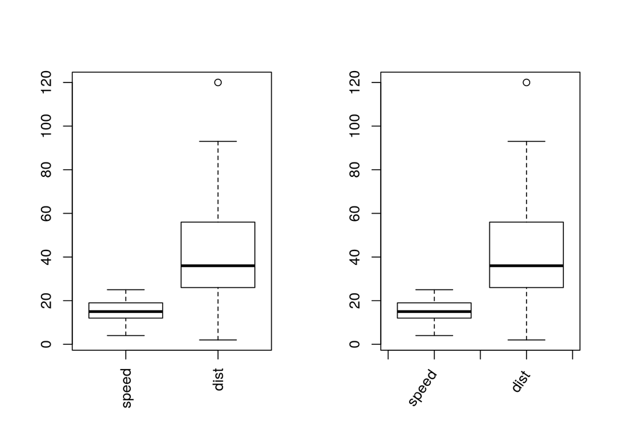

Figure 1: Rotations de *xlab*

```r
# méthode 1
par(mfrow = c(1,2))
boxplot(cars, las = 3)

# méthode 2
boxplot(cars, xaxt = "n",  xlab = "")
axis(1, labels = FALSE)
text(x =  seq_along(names(cars)), y = par("usr")[3] - 10, srt = 55, adj = 1,
     labels = names(cars), xpd = TRUE)
```

On remarque que c’est beaucoup plus facil avec le package [ggplot2](http://ggplot2.org/).

## 3.2 `legend()` en dehors d’un plot

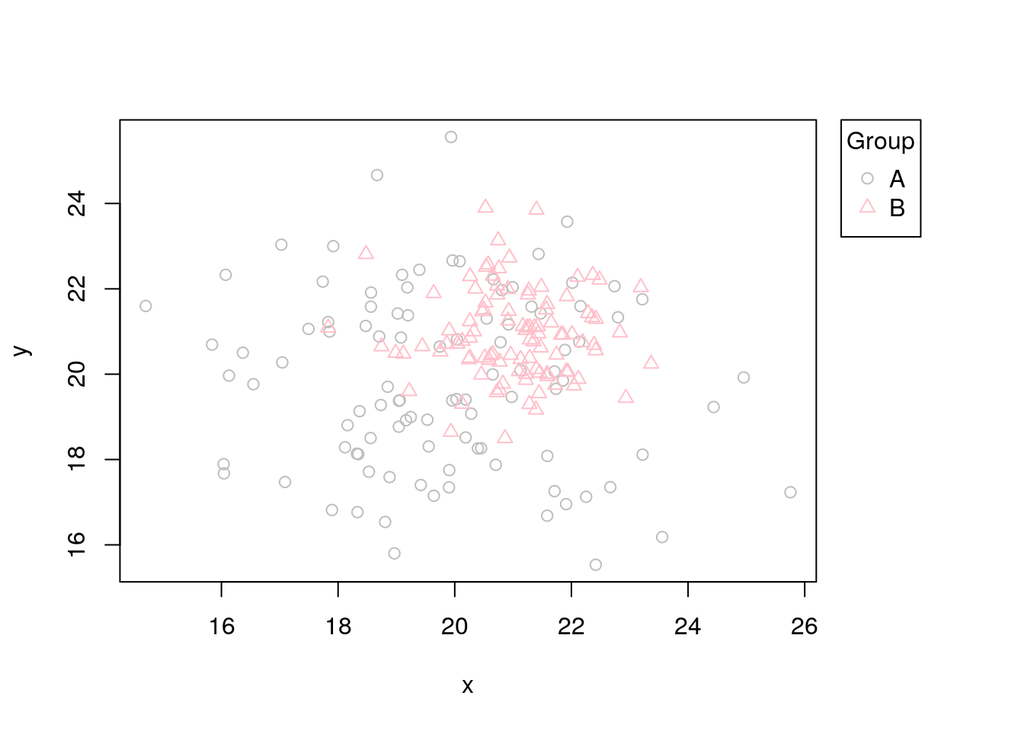

Figure 2: legend en dehor d’un plot

```r
# on va faire un plot de 2 nuages des points de dim 2
A <- data.frame(x=rnorm(100, 20, 2), y=rnorm(100, 20, 2))
B <- data.frame(x=rnorm(100, 21, 1), y=rnorm(100, 21, 1))

# ajuster la marge
# le default est c(5,4,4,2) + 0.1
# regarder ?par qu'est-ce qu'il représente
par(mar=c(5.1, 4.1, 4.1, 7.1), xpd=TRUE)

plot(y ~ x, A, ylim=range(c(A$y, B$y)), xlim=range(c(A$x, B$x)), pch=1, col='grey')
points(y ~ x, B, pch=2, col='pink')

legend("topright", inset=c(-0.15,0), legend=c("A","B"), pch=c(1,2), title="Group", col=c('grey','pink'))
```

# 4 Remarques sur les Devoirs à rendre

## 4.1 Devoir 1

Le devoir 1 est principalement un exo sur la rédaction et l’utilisation de Rmarkdown.

### 4.1.1 Camenbert (pie chart) ou non ?

Je ne sais pas si c’est très bizzare pour vous de ne voir pas du tout de camenbert pendant ce cours. Il me semble que c’est une histoire classique de parler camenbert quand on fait la stat. En revanche, dans la “vraie” stats, il y a très peu de cas ou un camenbert est util. [Pourquoi ?](https://medium.com/@KristinHenry/in-defense-of-pie-charts-and-why-you-shouldnt-use-them-df2e8ccb5f76)

### 4.1.2 Histogramme ou boxplot ?

Normalement, il n’existe pas un règle pour décider que s’il faut utiliser un boxplot ou une histogramme. Mais, ce qu’on peut dire est que, il faut pas poser les deux ensemble, car ils sont tous pour présenter les infos sur la distribution.

### 4.1.3 Gaussien ou pas ?

Mathématiquement, il n’existe pas de méthode pour tester si un échantillon suit une loi de gaussien ou non. En même temps, les hypothèses de type gaussien est souvent assurées par TCL. Donc, tracer l’histogramme d’un échantillon de taille très limitée ne va pas dire qqch sur cette histoire. Dans le problème de anorexie, il y a vers 30 données dans chaque groupe. Je vous donne un petit exemple intéressant.

On commence par simuler un échantillon de taille 1000, qui suit une loi normale centrée réduite.

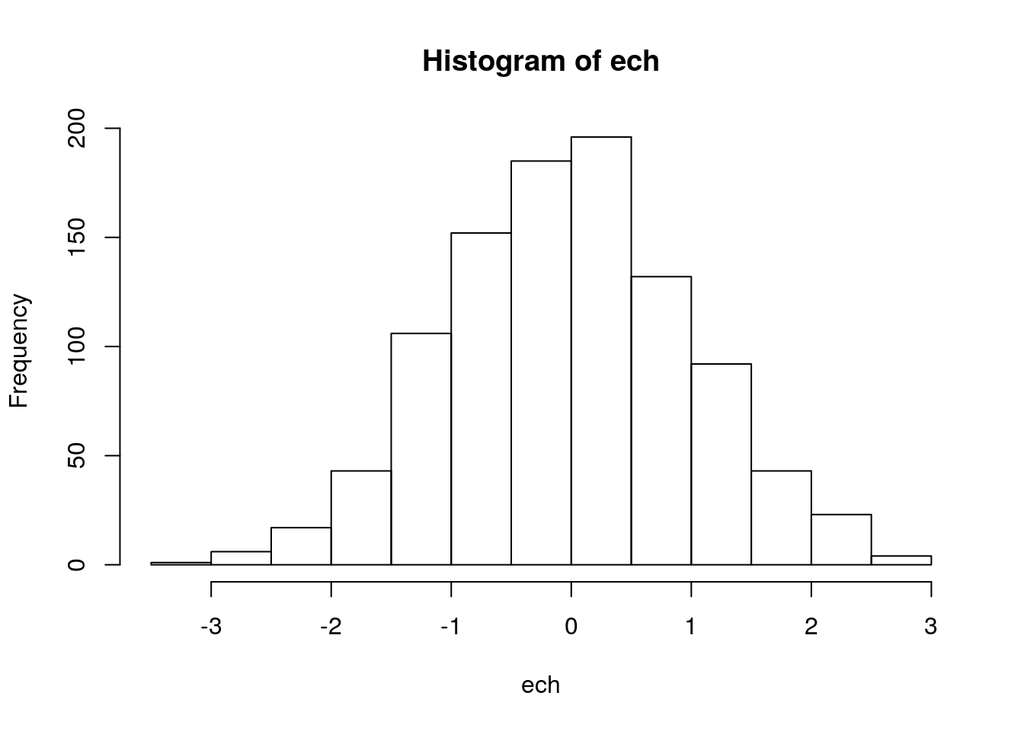

Figure 3: Un échantillon d’une loi normale

```r
ech <- rnorm(1000)
hist(ech)
```

En suite, on tire un échantillon de taille 30 parmi les 1000 observations qu’on a simulé.

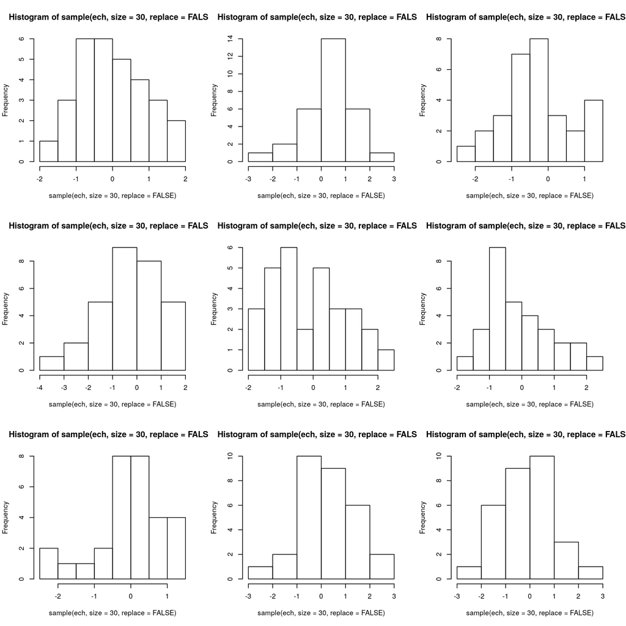

Figure 4: Un sous ensemble de taille 30

```r
par(mfrow = c(3,3))
replicate(9, hist(sample(ech, size = 30, replace = FALSE)))
```

Qu’est-ce qu’on observe ? Qu’est-ce qu’on peut conclure ?